# FrPr_PCA

Christopher Stewart

January 20, 2016

## Introduction

This file documents a reanalysis of Franco-Provençal questionnaire data originally performed using Principal Components Analysis (PCA). The aim is to examine questionnaire items that are potentially redundant, i.e. tap into the same latent variable, and to investigate procedures to collapse across such questions.

### Ingesting data, preliminary exploration and pruning

1. To begin, we load the dat into `R` and make a correlation matrix to see how the variables are related to each other:

```r
## set working directory
setwd("/Users/christopherstewart/Desktop/FrPr_PCA")

## actually load data into R
data <- read.csv(file = "modified recoded questionnaire data.csv", head = TRUE, sep = ",")

## make correlation matrix
suppressPackageStartupMessages(require("Hmisc"))
data_corrmat <- cor(data)
```

```
## Warning in cor(data): the standard deviation is zero
```

2. The `Warning message:` thrown by the creation of the correlation matrix reveals a valuable insight: some variables have zero variance (i.e. all the same value). Before continuing, we remove those variables:

```r
## loop through data set and find columns with only one unique value
### (N.B.: if we raise this to 3, there are 20 such columns!!!)
data_no_var <- apply(data, 2, function(x) length(unique(x)) == 1)
summary(data_no_var)
```

```
##    Mode   FALSE    TRUE    NA's
## logical      44       1       0
```

```r
## the 1 TRUE value indicates that 1 column has no variance (i.e. only one value); we remove that here and regenerate our correlation matrix
data_2 <- data[, !data_no_var]
data_corrmat_2 <- cor(data_2)
```

3. With the error gone, we now examine our new correlation matrix. First, we examine variables with |r| >= .9, i.e. variables that are almost perfectly correlated. For ease of reference, we import two functions to aid our exploration.

```r
## make an object that retains highly correlated variables (functions created by Stephen Turner (see https://gist.github.com/stephenturner/3492773))

cor.prob <- function (X, dfr = nrow(X) - 2) {
  R <- cor(X, use="pairwise.complete.obs")
  above <- row(R) < col(R)
  r2 <- R[above]^2
  Fstat <- r2 * dfr/(1 - r2)
  R[above] <- 1 - pf(Fstat, 1, dfr)
  R[row(R) == col(R)] <- NA
  R
}

flattenSquareMatrix <- function(m) {
  if( (class(m) != "matrix") | (nrow(m) != ncol(m))) stop("Must be a square matrix.")
  if(!identical(rownames(m), colnames(m))) stop("Row and column names must be equal.")
  ut <- upper.tri(m)
  data.frame(i = rownames(m)[row(m)[ut]],
             j = rownames(m)[col(m)[ut]],
             cor=t(m)[ut],
             p=m[ut])
}

## apply these functions to our correlation matrix to yield a more digestible output, then print out the five strongest correlations (|r| > .91, p = 0)
data_corrmat_3 <- flattenSquareMatrix(cor.prob(data_corrmat_2))
data_hi_corr <- data_corrmat_3[order(-abs(data_corrmat_3$cor)), ]
print(head(data_hi_corr, n = 5))
```

```
##                      i             j       cor p
## 171           L.UNCLES       L.AUNTS 0.9754991 0
## 55       L.WITH.MOTHER L.WITH.FATHER 0.9675343 0
## 136      L.GRANDFATHER L.GRANDMOTHER 0.9654378 0
## 91  L.WITH.ELDER.CHILD L.YOUNG.CHILD 0.9291136 0
## 10              l_best     l_bestExp 0.9147467 0
```

4. The names of these variables suggest they are highly similar, thus we elect to keep only the first one listed in the correlation matrix, this leaves us with 39 of the original 45 columns.

```r
dropped_cols <- c("L.AUNTS", "L.WITH.FATHER", "L.GRANDMOTHER", "L.YOUNG.CHILD", "l_bestExp")
data_3 <- data_2[, !(names(data_2) %in% dropped_cols)]
ncol(data_3)
```

```
## [1] 39
```

5. We now turn to the PCA. We immediately see that the first component accounts for *96.88% of the variance*, an account visualized in the scree plot. Bearing in mind that this “component” is essentially a linear combination of these variables that accounts for the highest possible degree of variance, it appears that this analysis may be an overly aggressive means of reducing the dimensionality of this questionnaire data.

```r
data_3_pca <- prcomp(data_3)
summary(data_3_pca)
```

```
## Importance of components:
##                            PC1     PC2     PC3     PC4     PC5     PC6
## Standard deviation     25.5553 1.92461 1.40753 1.27727 1.20009 1.12938
## Proportion of Variance  0.9688 0.00549 0.00294 0.00242 0.00214 0.00189
## Cumulative Proportion   0.9688 0.97428 0.97722 0.97964 0.98178 0.98367
##                            PC7     PC8     PC9    PC10   PC11    PC12
## Standard deviation     0.99810 0.97619 0.96007 0.87370 0.8603 0.78506
## Proportion of Variance 0.00148 0.00141 0.00137 0.00113 0.0011 0.00091
## Cumulative Proportion  0.98515 0.98656 0.98793 0.98906 0.9902 0.99107
##                           PC13    PC14    PC15    PC16    PC17    PC18
## Standard deviation     0.78240 0.71393 0.69264 0.67302 0.61256 0.60365
## Proportion of Variance 0.00091 0.00076 0.00071 0.00067 0.00056 0.00054
## Cumulative Proportion  0.99198 0.99274 0.99345 0.99412 0.99468 0.99522
##                           PC19    PC20    PC21   PC22    PC23    PC24
## Standard deviation     0.58815 0.56589 0.54592 0.5214 0.49340 0.48383
## Proportion of Variance 0.00051 0.00048 0.00044 0.0004 0.00036 0.00035
## Cumulative Proportion  0.99573 0.99621 0.99665 0.9970 0.99741 0.99776
##                           PC25    PC26    PC27    PC28   PC29    PC30
## Standard deviation     0.46503 0.44580 0.43368 0.39669 0.3713 0.33020
## Proportion of Variance 0.00032 0.00029 0.00028 0.00023 0.0002 0.00016
## Cumulative Proportion  0.99808 0.99837 0.99865 0.99889 0.9991 0.99925
##                           PC31    PC32   PC33    PC34    PC35    PC36
## Standard deviation     0.31110 0.28238 0.2588 0.25147 0.23481 0.21533
## Proportion of Variance 0.00014 0.00012 0.0001 0.00009 0.00008 0.00007
## Cumulative Proportion  0.99940 0.99952 0.9996 0.99971 0.99979 0.99986
##                           PC37    PC38    PC39
## Standard deviation     0.21293 0.17364 0.14046
## Proportion of Variance 0.00007 0.00004 0.00003
## Cumulative Proportion  0.99993 0.99997 1.00000
```

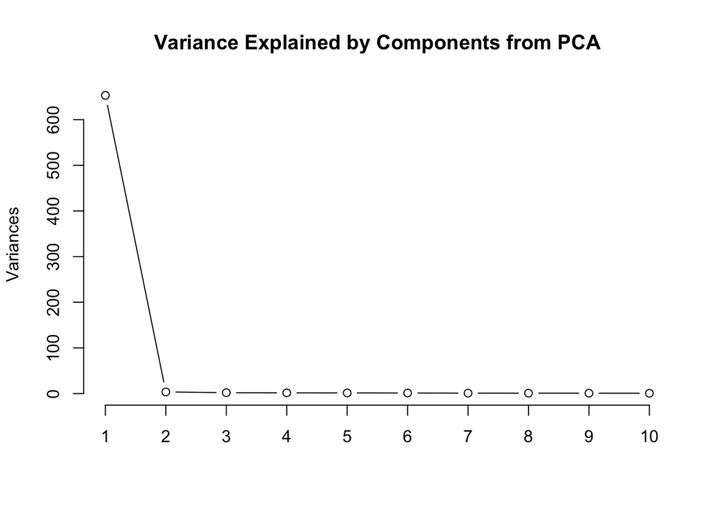

```r
plot(data_3_pca, type = "l", main = "Variance Explained by Components from PCA")
```